# Part II - Ford GoBike System Data Exploration

## Duration Distribution

> After standardizing by converting from seconds to minutes and then plotting on a logarithmic scale, the distribution of trip duration takes on a unimodal shape and shows that most trips taken lasted between 4 to 20 minutes

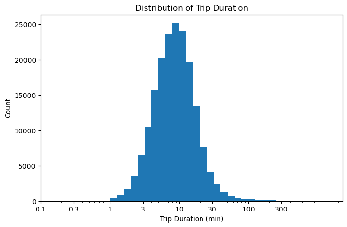

```python
log_bins = 0.1
bins=10 ** np.arange(0, np.log10(ford_bike_new['trip_duration'].max())+ log_bins, log_bins)

plt.figure(figsize=[8, 5])
plt.hist(data = ford_bike_new, x = 'trip_duration', bins = bins );
plt.xscale('log')
ticks = [0.1, 0.3, 1, 3, 10, 30, 100, 300]
labels = ['{}'.format(v) for v in ticks]
plt.xticks(ticks, labels)
plt.title('Distribution of Trip Duration')
plt.xlabel('Trip Duration (min)')
plt.ylabel('Count')

plt.show()
```

## Average trip duration by user type

> Customers (23.9 minutes) spent more time on trips on average than Subscribers (10.7 minutes). This might be because Subscribers mostly used the rides for short everyday comutes like going from home to work or to school

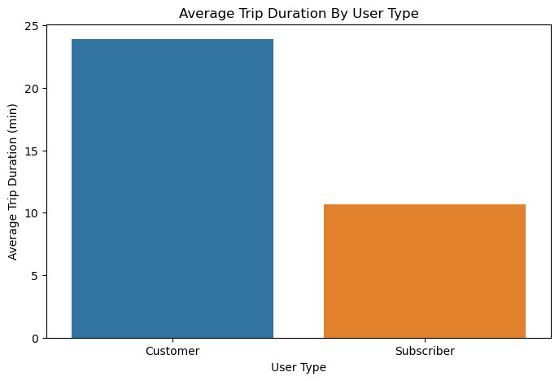

```
    user_type  average_duration
0    Customer              23.9
1  Subscriber              10.7
```

```python
# Calculate the average trip duration by user type
user_type_trips = np.round(ford_bike_new.groupby('user_type')['trip_duration'].mean(),1)

#Convert age_group_trips to a table using reset index
user_type_trips = user_type_trips.reset_index( name = 'average_duration')

plt.figure(figsize=[8,5])
sb.barplot(data = user_type_trips, x = 'user_type', y = 'average_duration')
plt.xlabel('User Type')
plt.ylabel('Average Trip Duration (min)')
plt.title('Average Trip Duration By User Type')
plt.show()

print(user_type_trips)
```

## Number Of Rides On Days Of The Week By User Type

> we can see that the day of the week that the highest number of trips (Thursday) is not dependent on the user type. The graph also shows that there is a reduction in the number of rides taken by Subscribers on Saturdays and Sundays, this is understandable because a lot of subscribers do not have to go to work during the weekends. As for casaul riders, there is not major change in the number of rides taken on different days of the week.

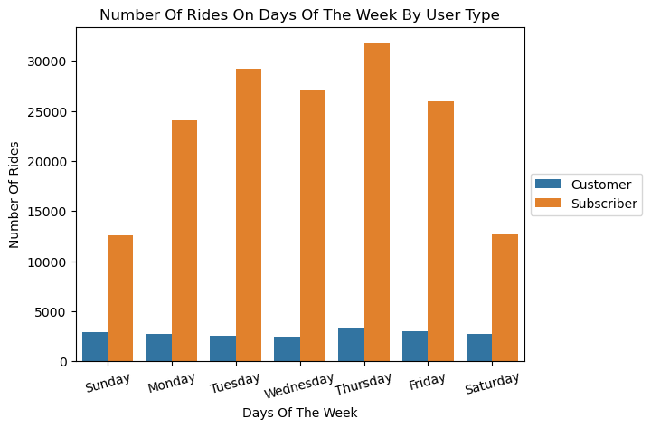

```python
 # plot a graph to see how different user types ride each day of week
sb.countplot(data = ford_bike_new, x = 'day_of_week', hue = 'user_type')
plt.xlabel('Days Of The Week')
plt.ylabel('Number Of Rides')
plt.xticks(rotation = 15)
plt.title('Number Of Rides On Days Of The Week By User Type')
plt.legend(loc='center left', bbox_to_anchor=(1, 0.5))
plt.show()
```

## Average trip duration for each user_type by the days of the week

Customers had longer rides on average than Subscribers for every day of the week with Sundays and Saturdays being signifantly higher than the rest of the week days

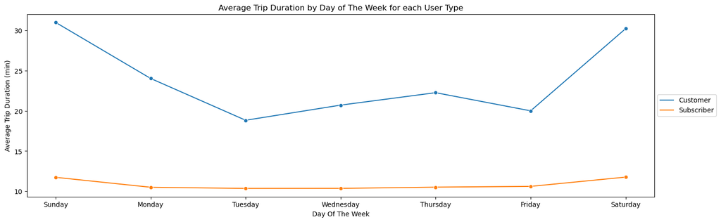

```python
 weekday_avg_use = ford_bike_new.groupby(['user_type','day_of_week']).trip_duration.mean()
weekday_avg_use = weekday_avg_use.reset_index()

# line plot with colors based on user_type
plt.figure(figsize=[17,5])
sb.lineplot(data = weekday_avg_use, x='day_of_week', y='trip_duration', hue='user_type', marker='o')
plt.title("Average Trip Duration by Day of The Week for each User Type")
plt.ylabel('Average Trip Duration (min)');
plt.xlabel('Day Of The Week')
plt.legend(loc='center left', bbox_to_anchor=(1, 0.5))
plt.show()
```

## Average trip duration by time of the day for each user_type

The Average trip duration for each time of the day for the Subscribers is relatively constant with slight increase in the afternoon while for Customers the average trip duration increases significantly in the afternoon and at night.

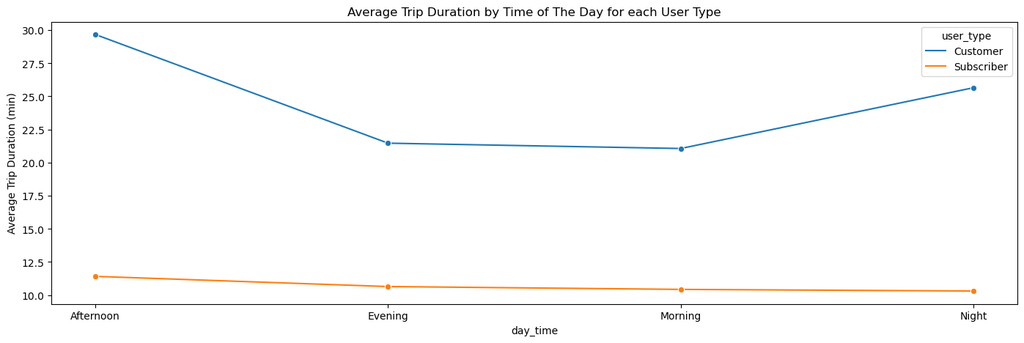

```python
avg_trip_by_user = ford_bike_new.groupby(['user_type','day_time']).trip_duration.mean()
avg_trip_by_user = avg_trip_by_user.reset_index()

# line plot with colors based on user_type
plt.figure(figsize=[17,5])
sb.lineplot(data = avg_trip_by_user, x = 'day_time', y = 'trip_duration', hue = 'user_type', marker = 'o')
plt.title("Average Trip Duration by Time of The Day for each User Type")
plt.ylabel('Average Trip Duration (min)');
plt.show()
```

## Summary

- The number of Subscriber trips is significantly Higher than that of Customer
- Customers (23.9 minutes) spent more time on trips on average than Subscribers (10.7 minutes). This might be because Subscribers mostly used the rides for short everyday comutes like going from home to work or to school
- There is a reduction in the number of rides taken by Subscribers on Saturdays and Sundays, this is understandable because a lot of subscribers do not have to go to work during the weekends. As for casaul riders, there is no major change in the number of rides taken on different days of the week.
- Customers had longer rides on average than Subscribers for every day of the week with Sundays and Saturdays being signifantly higher than the rest of the week days
- The Average trip duration for each time of the day for the Subscribers is relatively constant with slight increase in the afternoon while for Customers the average trip duration increases significantly in the afternoon and at night.